# EEG Feature Analysis

```r
#show_psd(d_concentrating_2_obj, "D - concentraitng - 2")
```

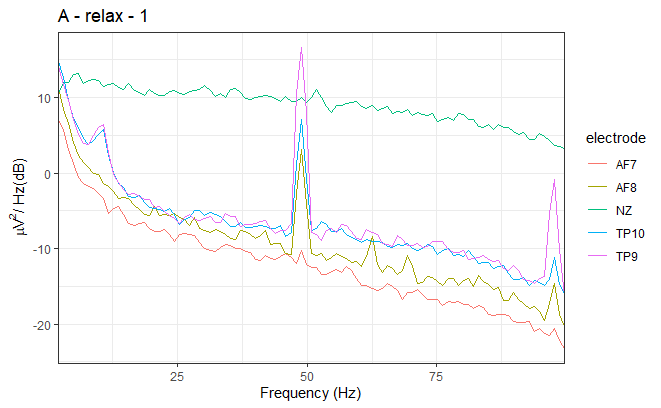

```r
show_psd(a_relaxed_1_obj, "A - relax - 1")
```

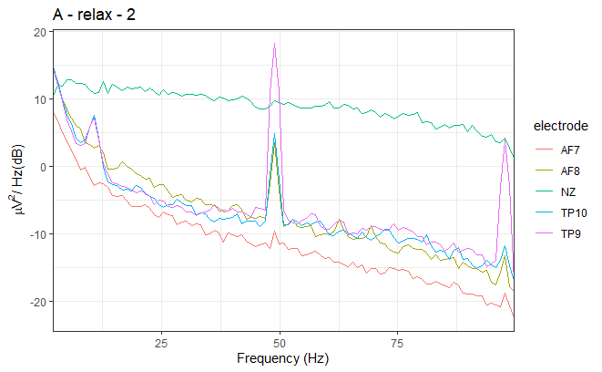

```r
show_psd(a_relaxed_2_obj, "A - relax - 2")
```

[figure not shown]

```r
show_psd(a_relaxed_1_obj, "B - relax - 1")
```

[figure not shown]

```r
show_psd(a_relaxed_2_obj, "B - relax - 2")
```

[figure not shown]

```r
show_psd(a_relaxed_1_obj, "C - relax - 1")
```

[figure not shown]

```r
show_psd(a_relaxed_2_obj, "C - relax - 2")
```

[figure not shown]

```r
show_psd(a_relaxed_1_obj, "D - relax - 1")
```

[figure not shown]

```r
show_psd(a_relaxed_2_obj, "D - relax - 2")
```

## Implications

Brain waves analysis enables effective interactions with a subject via BCI. In the article we showcase methods for removing artifacts from a signal (bandpass- and notch-filter). PSD was helpful during feature selection and the baseline is an example how to extract useful information from the signal. Leveraging this knowledge can lead to the creation of BCI systems that enable seamless and intuitive interactions between humans and software or computers, opening up new possibilities for communication, control, and interaction for various applications, including assistive technology, gaming, virtual reality, healthcare and education.